# Analysis of variance

Meidan Greenberg

January 2020

# **קורס תכנון ניסויים 5000571, תש"פ סמסטר א'**

# המחלקה לתעשיה וניהול, מכללת סמי שמעון באר שבע

## לידי: ד"ר יצחק מינצ'וק מגיש: מידן גרינברג, ת.ז 203547500

### הקדמה

במסגרת פרוייקט זה, ננתח ע"י שיטות שנלמדו בקורס את שאלת המחקר:  
האם ישנם הבדלים באחוזי ההשמה בין אזורי ההתיישבות במדינה?  
כלומר במילים אחרות, נרצה להשוות בין יעילות לשכות התעסוקה באזורים השונים בארץ.  
לשם כך, נעשה שימוש ב[בסיס נתונים ממשלתי](https://data.gov.il/dataset/e-data-gov-il-dataset-yeshuvmoatzadata) מטעם שירות התעסוקה.

### סטטיסטיקה תיאורית

לצורך הניסוי, נשווה בין אחוזי ההשמה של לשכות התעסוקה ב7 אזורים שונים בארץ שנדגמו במהלך השנים 2010-2019. המודל שאיתו נעבוד הוא בלוקים, כאשר:

**b = {2010-2019} = 10**  
**k = {Central, Haifa, Jerusalem, Judea and Samaria, North, South, Tel Aviv} = 7**

**Block model:**  
$yij = \mu +\alpha j+ \beta i +\epsilon ij$  
$(i=1,...,b | j=1,...,k)$  
Assumptions:  
(1) $\varepsilon ij \sim N(\mu, \sigma\varepsilon^{2})$ ב"ת  
(2) $\sum_{j = 1}^{k} \hat{\alpha j} = 0$  
(3) $\sum_{i = 1}^{b} \hat{\beta i} = 0$

את הנחות 2,3 נבדוק בהמשך.  
בשלב הראשוני, נשלוף את הנתונים הרלוונטיים לניסוי.

```r
infodata <- read.csv("infoyeshuv.csv",sep=",", header=TRUE, stringsAsFactors = FALSE)
infodata$OnlyYear <-  substr(infodata$Month,1,4)  #Adding Only Year new column
infodata$HasamotPerJob <- infodata$Placement.from.reference / infodata$Total.jobseekers #Adding % of Hasamot column

#Selecting values
totaldata <- infodata %>%
  group_by(Cbs.district, OnlyYear) %>%
  summarise(Hasamot_Mean = mean(HasamotPerJob)) %>%
  arrange(Cbs.district)
```

ננסה לחזות את התוצאות ע"י גרף.

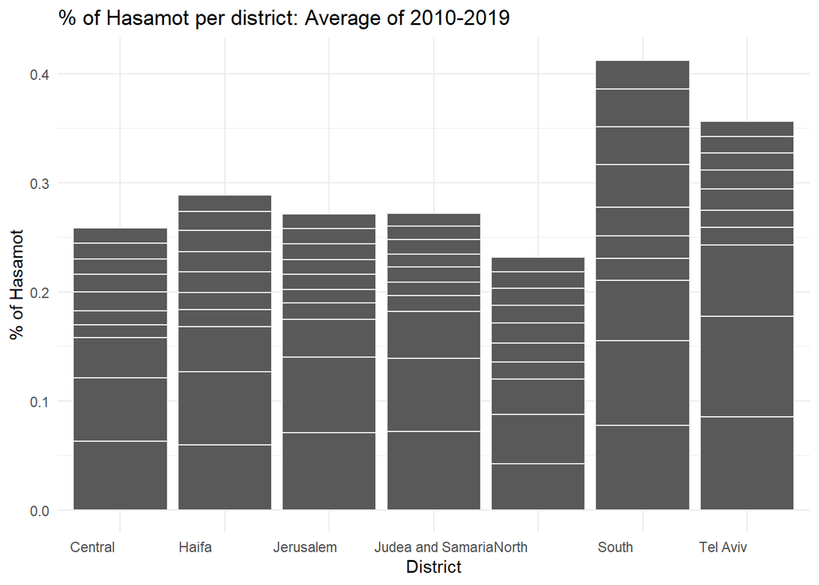

```r
ggplot(totaldata, aes(x=totaldata$Cbs.district, y=totaldata$Hasamot_Mean)) +
  geom_bar(stat = "identity", aes(x=totaldata$Cbs.district), color="gray95") + theme_minimal() +
  xlab("District")+ylab("% of Hasamot") +ggtitle("% of Hasamot per district: Average of 2010-2019")
```

ניתן לראות שאחוזי ההשמה הגבוהים ביותר שייכים ללשכות התעסוקה בדרום הארץ ובתל אביב.  
נמשיך לאמת זאת ע"י ניתוח שונות.  
נסדר את הנתונים בטבלה.

```r
#Creating table
datatable<-xtabs(totaldata$Hasamot_Mean ~ totaldata$OnlyYear + totaldata$Cbs.district)
names(dimnames(datatable)) <- c("Year", "District")
print.table(datatable)
```

```
##       District
## Year   Central                Haifa                 Jerusalem
##   2010             0.06261178            0.05931714             0.07050701
##   2011             0.05812649            0.06714543             0.06925599
##   2012             0.03696544            0.04148120             0.03512852
##   2013             0.01187121            0.01556941             0.01502485
##   2014             0.01296354            0.01590219             0.01186527
##   2015             0.01747340            0.01899923             0.01431266
##   2016             0.01607261            0.01803400             0.01355608
##   2017             0.01388688            0.01950510             0.01435571
##   2018             0.01435760            0.01762976             0.01383057
##   2019             0.01385422            0.01496878             0.01355407
##       District
## Year   Judea and Samaria North                South
##   2010        0.07166440           0.04210307           0.07750330
```

[output cut: 21 more lines]

בכדי לוודא שהנתונים שבטבלה אכן נכונים למודל, נשווה בין ממוצע ממוצעי העמודות, לבין ממוצע ממוצעי השורות, הרי שנקבל בשני המקרים את:

$\overline{y..} = \mu$

```r
mean(rowMeans(datatable))   #Yi.
```

```
## [1] 0.02987093
```

```r
mean(colMeans(datatable))   #Y.j
```

```
## [1] 0.02987093
```

```r
mean(rowMeans(datatable)) == mean(colMeans(datatable)) #Yi.=Y.j = Y..
```

```
## [1] TRUE
```

נבדוק את הנחה (2) לעיל, כלומר האם מתקיים:

$\sum_{j = 1}^{k} \hat{\alpha j} = 0$

כאשר:

$\hat{\alpha j} = \overline{y.j} - \overline{y..}$

```r
sumj<-0
for(j in 1:7) { #k=7
sumj <- sumj+ (mean(datatable[,j] - mean(colMeans(datatable))))
}
sumj
```

```
## [1] -1.387779e-17
```

הסכום שהתקבל שואף ל0. ומכאן נסיק שההנחה מתקיימת.  
נמשיך לבדיקת הנחה (3) לעיל, כלומר האם מתקיים

$\sum_{i = 1}^{b} \hat{\beta i} = 0$

כאשר:

$\hat{\beta i} = \overline{yi.} - \overline{y..}$

```r
sumi<-0
for(i in 1:10) { #b=10
sumi <- sumi+ (mean(datatable[i,] - mean(rowMeans(datatable))))
}
sumi
```

```
## [1] -1.040834e-17
```

גם כאן קיבלנו שהסכום שואף ל0.

### בדיקת הנחת התפלגות נורמלית

בכדי לבדוק הנחת התפלגות נורמלית, נשתמש ב2 כלים עיקריים:  
1. Q-Q Plot  
2. Kolmogorov Smirnof test

#### Q-Q Plot

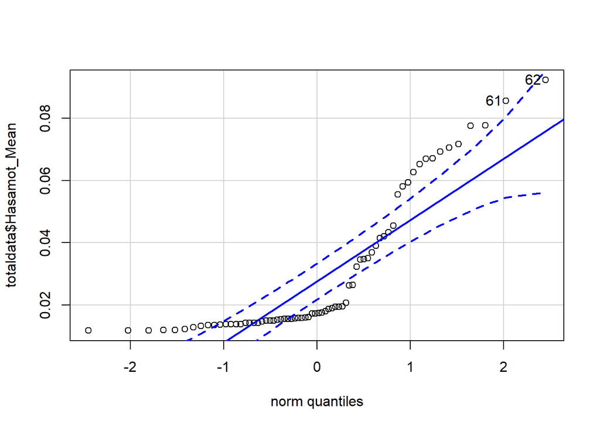

```
## [1] 62 61
```

```r
qqPlot(totaldata$Hasamot_Mean)
```

ניתן לראות שהנקודות שואפות להיצמד לקו המגמה, אך אי אפשר להגיד שהן נמצאות בטווחו.  
נמשיך לבדיקת קולמוגורוב-סמירנוף.

#### Kolmogorov - Snirnof Test

$when:$  
$Xi$= אחוזי ההשמה הכוללים של אזור i  
$H0: Xi\sim N(\mu, \sigma^{2})$  
$H1: else$

```r
ks.test(totaldata$Hasamot_Mean, pnorm)
```

```
##
##  One-sample Kolmogorov-Smirnov test
##
## data:  totaldata$Hasamot_Mean
## D = 0.50473, p-value < 2.2e-16
## alternative hypothesis: two-sided
```

ערך הסטטיסטי שקיבלנו (0.50473), אינו אופטימלי להחלטה כיוון שלא שואף ל0 או ל1. הנתון תואם לתצוגת הqqPlot.  
**היות וערך pValue שואף ל0, נוכל להסיק כי ייתכן ואחוזי ההשמה מתפלגים בצורה נורמלית כלשהי, אך לא בהכרח תחת התפלגות נורמלית סטנדרטית.**

### בדיקת שיוויון שונויות

לצורך בדיקת שיוויון שונויות בין הטיפולים (אזורים), נשתמש במבחן קוחרן היות וגודלי המדגם שווים.

$H0: \sigma 1^{2} = \sigma 2^{2} = ... = \sigma k^{2} = \sigma$  
$H1: else$

```r
#Cochran test
varj.vector <- c(var(datatable[,1]), var(datatable[,2]), var(datatable[,3]), var(datatable[,4]),
                var(datatable[,5]),var(datatable[,6]),var(datatable[,7]))

#Logical testing
max(varj.vector)/sum(varj.vector) >  0.3751 # G0.05,7,9
```

```
## [1] FALSE
```

### טבלת ANOVA

ניצור טבלת ANOVA וננתח את תוצאותה.

```r
anova.final <- aov(formula = totaldata$Hasamot_Mean ~ totaldata$Cbs.district +
                     totaldata$OnlyYear, data=totaldata)
summary(anova.final)
```

```
##                        Df   Sum Sq  Mean Sq F value   Pr(>F)
## totaldata$Cbs.district  6 0.002392 0.000399   8.701 1.24e-06 ***
## totaldata$OnlyYear      9 0.029531 0.003281  71.632  < 2e-16 ***
## Residuals              54 0.002474 0.000046
## ---
## Signif. codes:  0 '***' 0.001 '**' 0.01 '*' 0.05 '.' 0.1 ' ' 1
```

**ניתוח התוצאות:**  
ערכי F חושבו כך שהpValue שלהם נמוך יותר מ0.001, ולכן נשווה את הסטטיסטיים בטבלת F עבור ר"מ 0.001.  
נבדוק האם הבלוקים מובהקים, כלומר:

$H0: \beta 1 = \beta 2 = ... = \beta 10 = 0$  
$H1: else$

נבדוק האם מתקיים:

$F1(FOnlyYear) > Fdfblock, dfMSE,\alpha = F9,54,0.001 = 3.6$  
$F1 = 71.632 >> 3.6$

**נדחה H0 בר"מ 0.001 ונסיק כי הבלוקים מובהקים.**  
נמשיך לבדיקת הגורם.

$H0: \alpha 1 = \alpha 2 = ... = \alpha 7$  
$H1: else$

נבדוק האם מתקיים:

$F2(FDistrict) > FdfSSA, dfMSE,\alpha = F6,54,0.001 = 4.4$  
$F2 = 8.701 > 4.4$

**נדחה H0 בר"מ 0.001 ונסיק כי יש הבדלים באחוזי ההשמות בין האזורים השונים בארץ.**  
נמשיך לקבוצות הומוגניות

### קבוצות הומוגניות

נבדוק את הומוגניות האזורים השונים בארץ בעזרת מבחן דנקן.

```r
#Duncan test

out<- duncan.test(anova.final, "totaldata$Cbs.district", console =TRUE)
```

```
##
## Study: anova.final ~ "totaldata$Cbs.district"
##
## Duncan's new multiple range test
## for totaldata$Hasamot_Mean
##
## Mean Square Error:  4.580682e-05
##
## totaldata$Cbs.district,  means
##
##                        totaldata.Hasamot_Mean        std  r        Min
## Central                            0.02581832 0.01961594 10 0.01187121
## Haifa                              0.02885522 0.01977171 10 0.01496878
## Jerusalem                          0.02713907 0.02350552 10 0.01186527
## Judea and Samaria                  0.02721107 0.02418421 10 0.01193105
## North                              0.02318930 0.01210260 10 0.01378549
## South                              0.04123426 0.02175514 10 0.01964096
## Tel Aviv                           0.03564929 0.03198808 10 0.01425509
##                               Max
## Central                0.06261178
## Haifa                  0.06714543
## Jerusalem              0.07050701
## Judea and Samaria      0.07166440
## North                  0.04550277
## South                  0.07760772
## Tel Aviv               0.09219846
##
## Alpha: 0.05 ; DF Error: 54
##
## Critical Range
##           2           3           4           5           6           7
## 0.006068318 0.006383030 0.006590269 0.006740733 0.006856426 0.006948815
##
## Means with the same letter are not significantly different.
##
##                        totaldata$Hasamot_Mean groups
## South                              0.04123426      a
## Tel Aviv                           0.03564929      a
## Haifa                              0.02885522      b
## Judea and Samaria                  0.02721107      b
## Jerusalem                          0.02713907      b
## Central                            0.02581832      b
## North                              0.02318930      b
```

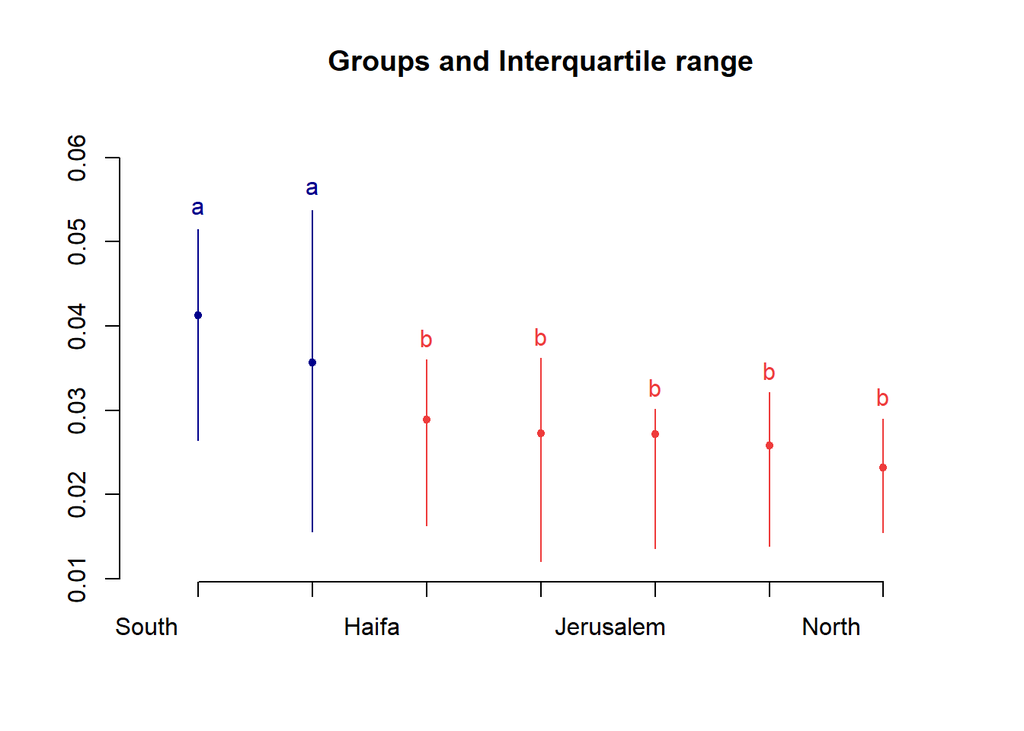

```r
plot(out,variation="IQR")
```

בפלט קיבלנו את הקבוצות ההומוגניות:  
a = {דרום, תל אביב}  
b = {צפון, ירושלים, יהודה ושומרון, מרכז, חיפה}  
**כאשר עבור קבוצה a, אחוזי ההשמה הם הגבוהים ביותר.**